# Digital footprint analysis

Ricardo Primi

2022-04-10

### Le dados e explora base

1. Lê os dados
- Visitas (cliques) de 7 sujeitos em 6 sites

```r
library(readxl)

resp_digfoot <- read_excel("../data/resp_footprintxlsx.xlsx")
names(resp_digfoot)
```

```
## [1] "subj"           "google"         "FB"             "etsy"
## [5] "deviantart"     "rottentomatoes" "imdb"
```

```r
str(resp_digfoot )
```

```
## tibble [7 × 7] (S3: tbl_df/tbl/data.frame)
##  $ subj          : chr [1:7] "Jason" "Neville" "David" "Susan" ...
##  $ google        : num [1:7] 13 30 14 5 0 0 6
##  $ FB            : num [1:7] 9 25 13 0 0 4 0
##  $ etsy          : num [1:7] 0 6 17 27 17 14 0
##  $ deviantart    : num [1:7] 0 0 21 33 15 16 0
##  $ rottentomatoes: num [1:7] 0 7 0 0 0 22 12
##  $ imdb          : num [1:7] 0 0 0 0 0 34 11
```

2. Calcula correlação entre as colunas(visitas aos websites)

```r
r = cor(resp_digfoot[ , 2:7])
print(r, digits = 2 )
```

```
##                google     FB   etsy deviantart rottentomatoes    imdb
## google           1.00  0.942 -0.370    -0.4544         -0.216 -0.4578
## FB               0.94  1.000 -0.292    -0.3959         -0.075 -0.2679
## etsy            -0.37 -0.292  1.000     0.9687         -0.243 -0.0580
## deviantart      -0.45 -0.396  0.969     1.0000         -0.223 -0.0025
## rottentomatoes  -0.22 -0.075 -0.243    -0.2230          1.000  0.9384
## imdb            -0.46 -0.268 -0.058    -0.0025          0.938  1.0000
```

3. Mostra correlações mais “bonitinhas” com o pacote corrr

```r
library(corrr)
r2 <- correlate(resp_digfoot[ , 2:7], quiet = TRUE)
shave(r2, upper = F)
```

```
## # A tibble: 6 × 7
##   term           google     FB   etsy deviantart rottentomatoes     imdb
##   <chr>           <dbl>  <dbl>  <dbl>      <dbl>          <dbl>    <dbl>
## 1 google             NA  0.942 -0.370     -0.454        -0.216  -0.458
## 2 FB                 NA NA     -0.292     -0.396        -0.0750 -0.268
## 3 etsy               NA NA     NA          0.969        -0.243  -0.0580
## 4 deviantart         NA NA     NA         NA            -0.223  -0.00247
## 5 rottentomatoes     NA NA     NA         NA            NA       0.938
## 6 imdb               NA NA     NA         NA            NA      NA
```

```r
fashion(r2)
```

```
##             term google   FB etsy deviantart rottentomatoes imdb
## 1         google         .94 -.37       -.45           -.22 -.46
## 2             FB    .94      -.29       -.40           -.07 -.27
## 3           etsy   -.37 -.29             .97           -.24 -.06
## 4     deviantart   -.45 -.40  .97                      -.22 -.00
## 5 rottentomatoes   -.22 -.07 -.24       -.22                 .94
## 6           imdb   -.46 -.27 -.06       -.00            .94
```

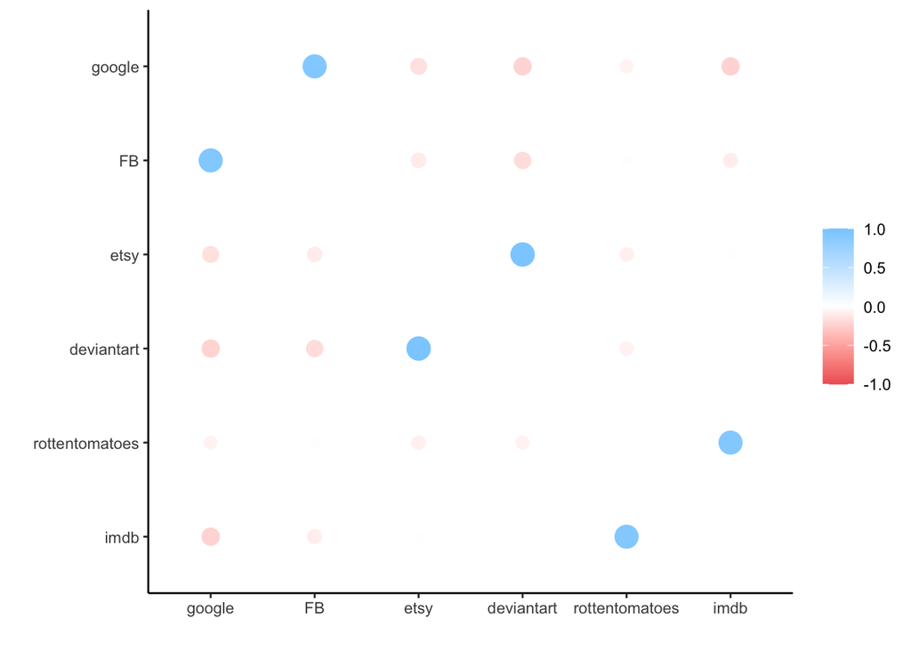

```r
rplot(r2)
```

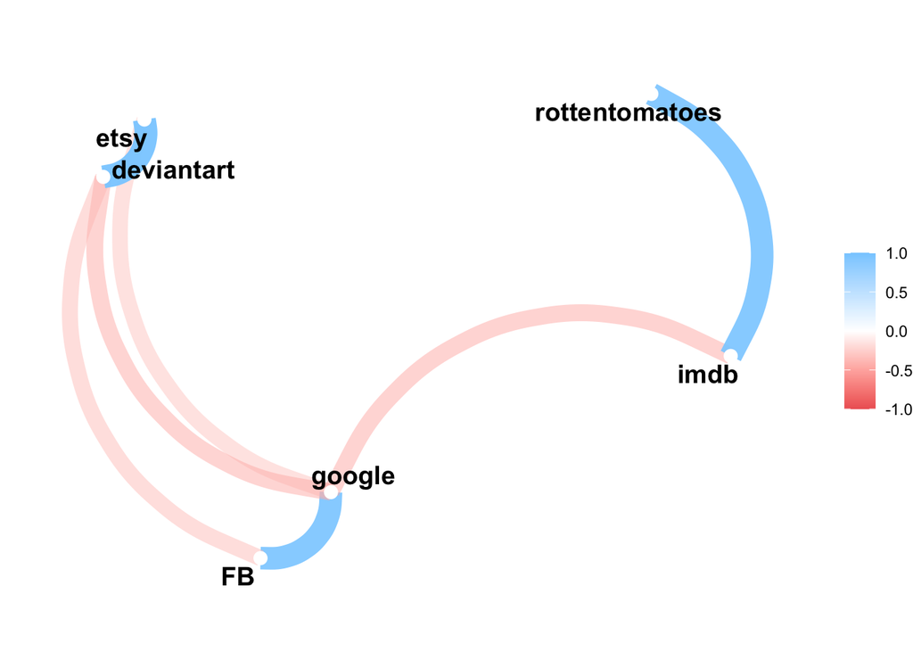

```r
network_plot(r2)
```

4. Agora usando o pacote heatmap

```r
devtools::install_github("talgalili/d3heatmap")
library(d3heatmap)
d3heatmap(r)
```

[interactive chart not shown]

### Um pouco de algebra com matrizes

1. Matrizes
- um vetor

```r
A = c(1, 2, 3, 4, 5, 6)
A
```

```
## [1] 1 2 3 4 5 6
```

- agora organizando o vetor em uma matriz

```r
  A = matrix(data = c(1, 2, 3, 4, 5, 6), nrow = 3, ncol = 2)
  A
```

```
##      [,1] [,2]
## [1,]    1    4
## [2,]    2    5
## [3,]    3    6
```

- note que ele distribuiu os números do vetor por coluna. Se quiséssemos por linha:

```r
 A = matrix(data = c(1, 2, 3, 4, 5, 6), nrow = 3, ncol = 2, byrow = TRUE)
 A
```

```
##      [,1] [,2]
## [1,]    1    2
## [2,]    3    4
## [3,]    5    6
```

- matriz B

```r
B = matrix(data = c(1, 1, 1, 2, 2, 2), nrow = 2, ncol = 3,  byrow = TRUE)
B
```

```
##      [,1] [,2] [,3]
## [1,]    1    1    1
## [2,]    2    2    2
```

- Multiplicação de matrizes

```r
C = A %*% B
C
```

```
##      [,1] [,2] [,3]
## [1,]    5    5    5
## [2,]   11   11   11
## [3,]   17   17   17
```

- Matriz transposta

```r
A
```

```
##      [,1] [,2]
## [1,]    1    2
## [2,]    3    4
## [3,]    5    6
```

```r
t(A)
```

```
##      [,1] [,2] [,3]
## [1,]    1    3    5
## [2,]    2    4    6
```

- Matriz diagnonal

```r
diag(C)
```

```
## [1]  5 11 17
```

### Análise de componentes principais

1. Calcula componentes principais da matriz `resp_digfoot` usando o pacote psych

```r
library(psych)
results <- principal(resp_digfoot[ , 2:7], nfactors = 3, scores = T)
```

2. Um pouco de álgebra da PC: decomposição da matriz em eigenvaules and eigenvectors (autovalores e autovetores)
- Ver livro de Psicometria de Wiliam Revele https://personality-project.org/r/book/ Cap. 6
- Decompõe a matriz em autovalores e autovetores

```r
 e <- eigen(r)
 str(e)
```

```
## List of 2
##  $ values : num [1:6] 2.7917 2.1955 0.9241 0.0539 0.0327 ...
##  $ vectors: num [1:6, 1:6] -0.541 -0.496 0.419 0.46 0.104 ...
##  - attr(*, "class")= chr "eigen"
```

```r
 e$values
```

```
## [1] 2.791725469 2.195514720 0.924108059 0.053924246 0.032686482 0.002041024
```

```r
 e$vectors
```

```
##            [,1]        [,2]       [,3]        [,4]       [,5]       [,6]
## [1,] -0.5408103 -0.13667339 -0.3675032 -0.51784190  0.2926393  0.4472001
## [2,] -0.4961230 -0.06805388 -0.5563246  0.53936156 -0.1492095 -0.3557515
## [3,]  0.4185960 -0.37657649 -0.4497708 -0.07754737 -0.6057941  0.3281366
## [4,]  0.4597419 -0.34759812 -0.3766441 -0.06385232  0.6330724 -0.3479862
## [5,]  0.1043392  0.62049011 -0.3420306 -0.51452074 -0.2198053 -0.4172223
## [6,]  0.2528126  0.57362598 -0.3070908  0.40756174  0.2757122  0.5202023
```

- calcula os componentes (a matriz de cargas das variáveis) *Principal components are simply the eigenvectors scaled by the square root of the eigenvalues*

```r
 sqrt(e$values)
```

```
## [1] 1.67084573 1.48172694 0.96130539 0.23221595 0.18079403 0.04517769
```

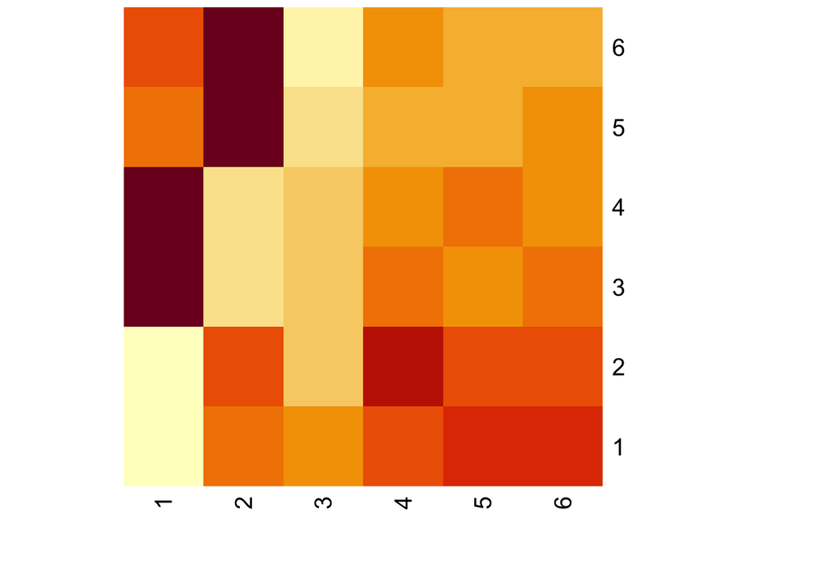

```r
 raiz_eigva <- diag(sqrt(e$values))
 c <-  e$vectors %*% raiz_eigva

 heatmap(c, Rowv = NA, Colv = NA)
```

```r
 round(c, 2)
```

```
##       [,1]  [,2]  [,3]  [,4]  [,5]  [,6]
## [1,] -0.90 -0.20 -0.35 -0.12  0.05  0.02
## [2,] -0.83 -0.10 -0.53  0.13 -0.03 -0.02
## [3,]  0.70 -0.56 -0.43 -0.02 -0.11  0.01
## [4,]  0.77 -0.52 -0.36 -0.01  0.11 -0.02
## [5,]  0.17  0.92 -0.33 -0.12 -0.04 -0.02
## [6,]  0.42  0.85 -0.30  0.09  0.05  0.02
```

- reproduz a matriz a partir da multiplicação dos componentes

```r
r2 <-   c %*% t(c)
round(r2 - r, 2)
```

```
##                google FB etsy deviantart rottentomatoes imdb
## google              0  0    0          0              0    0
## FB                  0  0    0          0              0    0
## etsy                0  0    0          0              0    0
## deviantart          0  0    0          0              0    0
## rottentomatoes      0  0    0          0              0    0
## imdb                0  0    0          0              0    0
```

- o objetico final é tentar reproduzir a matriz udando um numero menor de componentes *Is it possible to represent this matrix in a more parsimonious way? That is, can we determine the vector f that generated the correlation matrix. (This is sometimes seen as the problem of unscrambling eggs.)*
- matriz = interação (omelete), componentes e escores fatoriais = efeitos principais (ingredientes)

```r
c2 <-  e$vectors[ , 1:3] %*% raiz_eigva[1:3, 1:3]
r3 <-   c2 %*% t(c2)
round(r3 - r, 2)
```

```
##                google    FB  etsy deviantart rottentomatoes  imdb
## google          -0.02  0.02  0.00      -0.01          -0.01  0.01
## FB               0.02 -0.02  0.00       0.00           0.01 -0.01
## etsy             0.00  0.00 -0.01       0.01          -0.01  0.01
## deviantart      -0.01  0.00  0.01      -0.01           0.00  0.00
## rottentomatoes  -0.01  0.01 -0.01       0.00          -0.02  0.01
## imdb             0.01 -0.01  0.01       0.00           0.01 -0.01
```

### Calculando Singular value decomposition

```r
library(irlba)
```

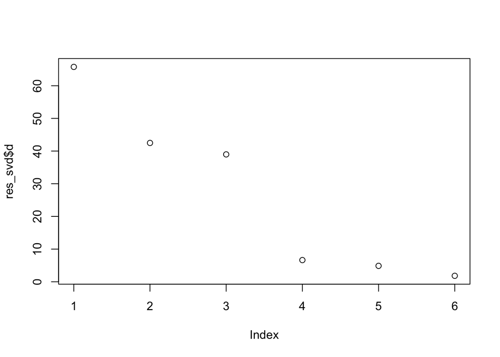

```r
res_svd <-  svd(as.matrix(resp_digfoot[ , 2:7]), nv = 3)
u <- res_svd$u
v <- res_svd$v
s = diag(res_svd$d)

plot(res_svd$d)
```

```r
resp_digfoot2 <- u[, 1:3] %*% s[1:3, 1:3] %*% t(v)

round(resp_digfoot[ , 2:7] - resp_digfoot2, 2)
```

```
##   google    FB  etsy deviantart rottentomatoes  imdb
## 1   1.04 -0.75 -0.99       0.71          -1.51  1.15
## 2  -0.39  0.09  1.16      -0.92           0.81 -0.60
## 3  -0.89  1.59 -1.46       1.20          -1.16  0.73
## 4   1.38 -1.79 -0.57       0.46           0.88 -0.49
## 5  -0.57  0.14  2.64      -2.16           0.57 -0.46
## 6  -0.96  1.41  0.03      -0.03          -1.03  0.63
## 7   2.61 -3.69 -0.38       0.32           2.44 -1.47
```

### Desfio: compare PC com SVD?